# Моментум-стратегии и reality check - с весами

> Количество исследумых компаний – **52**

#### **Таблица 1. Исследуемые компании**

|  | TICKERS | SHORT_NAME | INDUSTRY_SECTOR | INDUSTRY_GROUP | CUR_MKT_CAP | EQY_FREE_FLOAT_PCT | Mar.CAP.Adj..on.free.float |
| --- | --- | --- | --- | --- | --- | --- | --- |
| 1 | AFKS RX Equity | SISTEMA JSFC | Communications | Telecommunications | 163857000000 | 32.88 | 53876673171 |
| 2 | AFLT RX Equity | AEROFLOT | Consumer. Cyclical | Airlines | 45501949770.03 | 40.44 | 18400588069.84 |
| 3 | AKRN RX Equity | ACRON | Basic Materials | Chemicals | 91931112000 | 15.36 | 14119699492.08 |
| 4 | ALRS RX Equity | ALROSA AO | Basic Materials | Mining | 493158098584.8 | 22.88 | 112834079798.1 |
| 5 | BANE RX Equity | BASHNEFT | Energy | Oil&amp;Gas | 305809000000 | 15.67 | 47907242836.6 |
| 6 | BISV RX Equity | BASHINFORMSVYAZ | Communications | Telecommunications | 7924349064 | 100 | 7924349064 |
| 7 | BSPB RX Equity | BANK ST PETERSBU | Financial | Banks | 18197535600 | 32.13 | 5846304064.68 |
| 8 | CHMF RX Equity | SEVERSTAL PAO | Basic Materials | Iron/Steel | 515113204034 | 20.78 | 107048971654.81 |
| 9 | DIXY RX Equity | DIXY GROUP | Consumer. Non-cyclical | Food | 49213875000 | 45.01 | 22152149415 |
| 10 | ENRU RX Equity | ENEL RUSSIA OJSC | Utilities | Electric | 32542146500.4 | 17.14 | 5577723910.17 |

[output cut: 42 more lines]

> Период отслеживания менялся от **1** до **12** месяцев

> Период ожидания менялся от **0** до **8** недель

> Период инвестирования менялся от **1** до **12** месяцев

## 1. Моментум стратегии при весах (7,6,5,3,2,1,1,2,3,5,6,7)/24. Ранжирование по средней доходности (бенчмарк 6% годовых - только для reality check)

> Всего было рассмотрено **1296** стратегий

#### **Таблица 2. Все стратегии**

|  | mean | t | p-value | hist_per | moment_per | invest_per | Amount_of_negative |
| --- | --- | --- | --- | --- | --- | --- | --- |
| 1 | 0.006242 | 1.020003 | 0.311096 | 4 | 0 | 4 | 38 |
| 2 | 0.006083 | 1.778298 | 0.079519 | 4 | 0 | 8 | 29 |
| 3 | 0.006093 | 1.816289 | 0.073432 | 4 | 0 | 12 | 36 |
| 4 | 0.005167 | 1.902868 | 0.061002 | 4 | 0 | 16 | 38 |
| 5 | 0.004271 | 1.799392 | 0.076089 | 4 | 0 | 20 | 31 |
| 6 | 0.005293 | 2.284491 | 0.025251 | 4 | 0 | 24 | 30 |
| 7 | 0.008087 | 3.814358 | 0.000283 | 4 | 0 | 28 | 24 |
| 8 | 0.00989 | 4.707862 | 1.2e-05 | 4 | 0 | 32 | 25 |
| 9 | 0.01072 | 4.392291 | 3.7e-05 | 4 | 0 | 36 | 29 |
| 10 | 0.011846 | 4.73399 | 1.1e-05 | 4 | 0 | 40 | 25 |

[output cut: 1286 more lines]

> Лучшая по средней доходности стратегия дает среднемесячную доходность **2.93** **%** и имеет параметры: период отбора – **11** месяцев, период ожидания – **3** недель, период инвестирования – **3** месяцев

> Bootstrap p-value равен **0.09**

> Всего портфелей у лучшей стратегии – **74** Количество отрицательных доходностей у лучшей стратегии – **13** ( **17.57%** )

#### **Рисунок 1.**

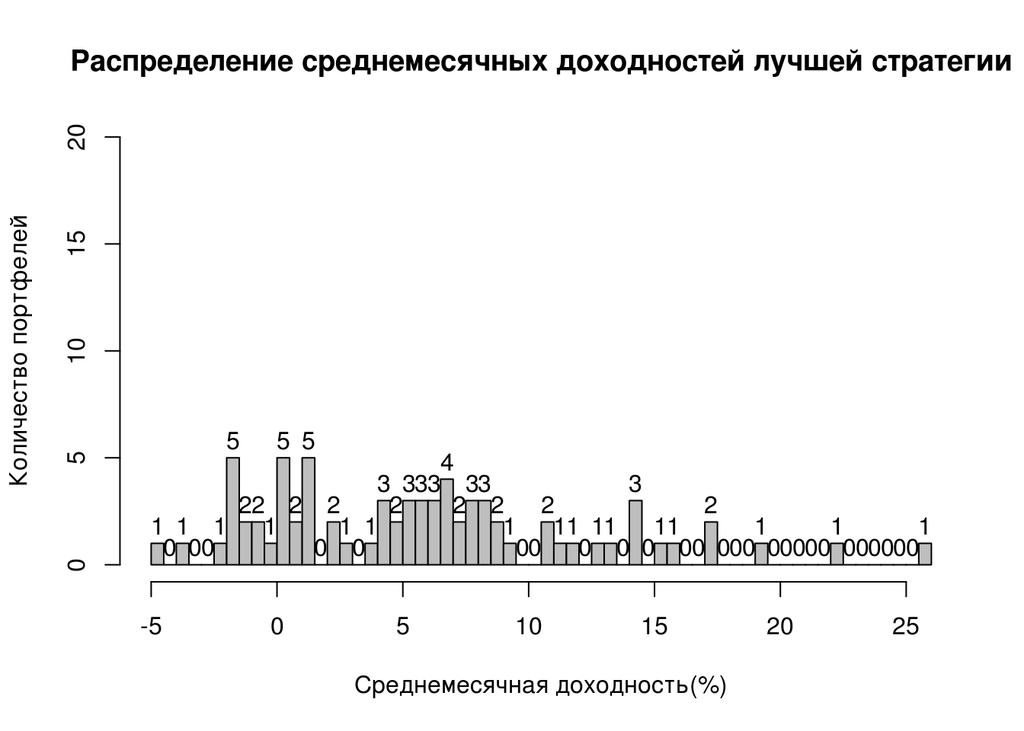

### **Вхождение в победителей и проигравших для лучшей стратегии**

#### **Рисунок 2.**

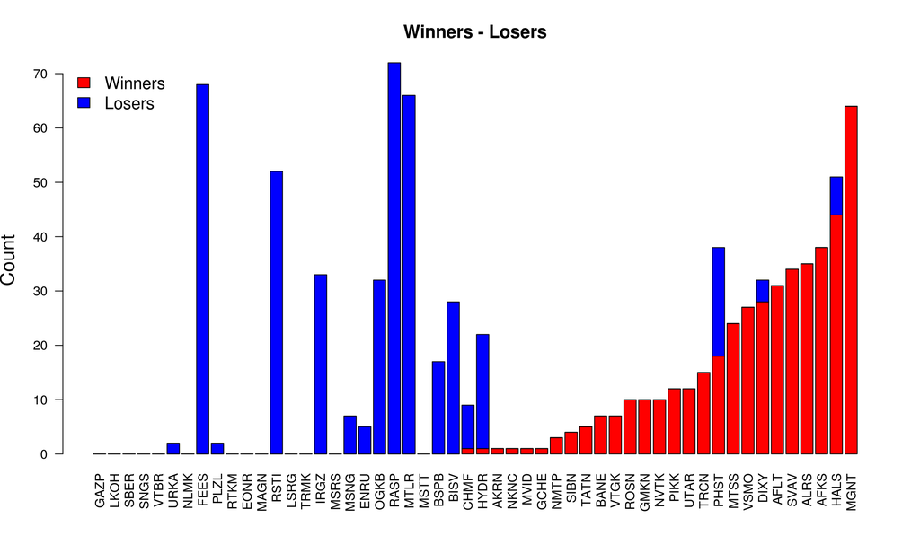

#### **Рисунок 3.**

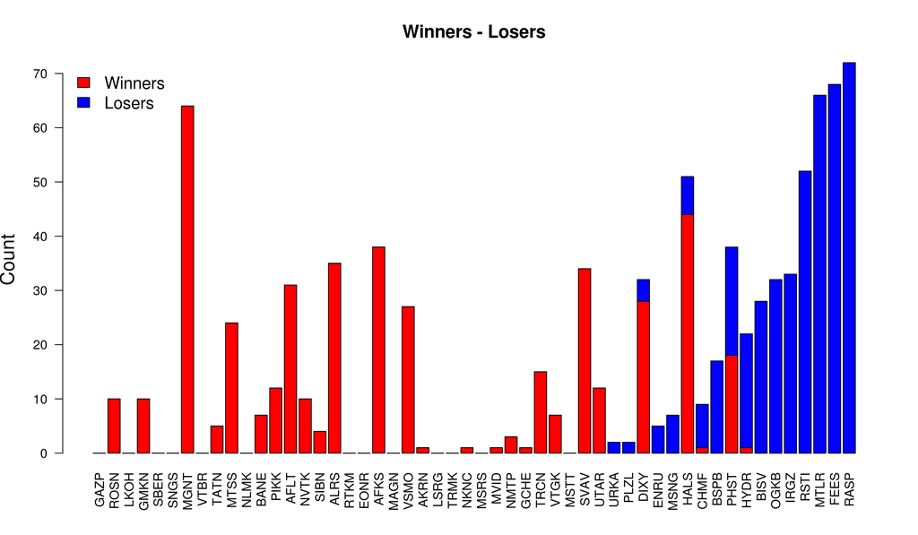

#### **Таблица 3. Вхождение компаний в победители и проигравшие для лучшей по средней доходности стратегии**

|  | Ticket | In_winners | In_losers |
| --- | --- | --- | --- |
| 1 | GAZP.RX.Equity | 0 | 0 |
| 2 | ROSN.RX.Equity | 10 | 0 |
| 3 | LKOH.RX.Equity | 0 | 0 |
| 4 | GMKN.RX.Equity | 10 | 0 |
| 5 | SBER.RX.Equity | 0 | 0 |
| 6 | SNGS.RX.Equity | 0 | 0 |
| 7 | MGNT.RX.Equity | 64 | 0 |
| 8 | VTBR.RX.Equity | 0 | 0 |
| 9 | TATN.RX.Equity | 5 | 0 |
| 10 | CHMF.RX.Equity | 1 | 8 |

[output cut: 42 more lines]

## 2. Моментум стратегии при весах (7,6,5,3,2,1,1,2,3,5,6,7)/24. Ранжирование по t-статистике (бенчмарк 6% годовых - только для reality check)

> Лучшая по t-статистике стратегия дает среднемесячную доходность **1.97** **%** и имеет параметры: период отбора – **12** месяцев, период ожидания – **8** недель, период инвестирования – **7** месяцев

> Bootstrap p-value равен **0.016**

> Всего портфелей у лучшей по t-статистике стратегии – **74** Количество отрицательных доходностей у лучшей по t-статистике стратегии – **2** ( **2.7%** )

#### **Рисунок 4.**

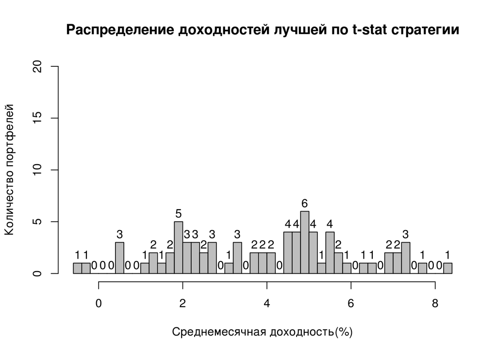

### **Вхождение в победителей и проигравших для лучшей стратегии**

#### **Рисунок 5.**

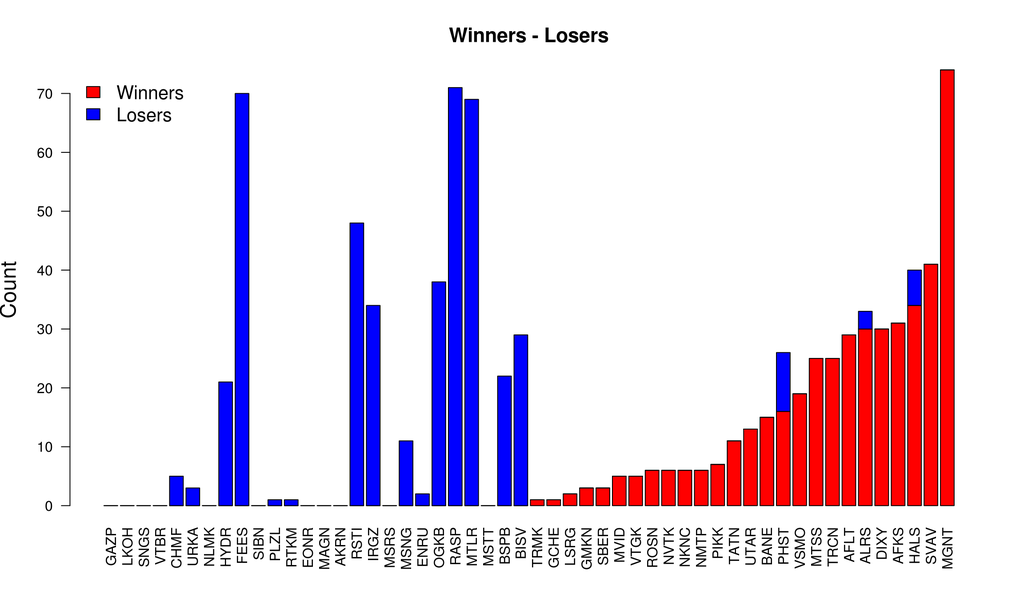

#### **Рисунок 6.**

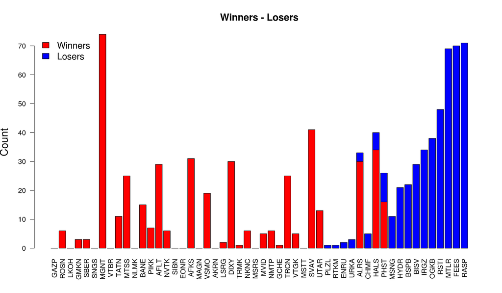

#### **Таблица 4. Вхождение компаний в победители и проигравшие для лучшей по t-статистике стратегии**

|  | Ticket | In_winners | In_losers |
| --- | --- | --- | --- |
| 1 | GAZP.RX.Equity | 0 | 0 |
| 2 | ROSN.RX.Equity | 6 | 0 |
| 3 | LKOH.RX.Equity | 0 | 0 |
| 4 | GMKN.RX.Equity | 3 | 0 |
| 5 | SBER.RX.Equity | 3 | 0 |
| 6 | SNGS.RX.Equity | 0 | 0 |
| 7 | MGNT.RX.Equity | 74 | 0 |
| 8 | VTBR.RX.Equity | 0 | 0 |
| 9 | TATN.RX.Equity | 11 | 0 |
| 10 | CHMF.RX.Equity | 0 | 5 |

[output cut: 42 more lines]

## 3. Моментум стратегии при весах (7,6,5,3,2,1,1,2,3,5,6,7)/24. Ранжирование по средней доходности (бенчмарк 6% годовых) для компаний с максимальной рыночной капитализацией (всего 32 компании)

> Всего было рассмотрено **1296** стратегий

#### **Таблица 5. Все стратегии**

|  | mean | t | p-value | hist_per | moment_per | invest_per | Amount_of_negative |
| --- | --- | --- | --- | --- | --- | --- | --- |
| 1 | -0.00092 | 0.1042 | 0.917296 | 4 | 0 | 4 | 36 |
| 2 | 0.005413 | 1.112694 | 0.269491 | 4 | 0 | 8 | 34 |
| 3 | 0.003885 | 0.980598 | 0.33003 | 4 | 0 | 12 | 33 |
| 4 | 0.001768 | 0.551106 | 0.583244 | 4 | 0 | 16 | 33 |
| 5 | 0.000771 | 0.314697 | 0.75389 | 4 | 0 | 20 | 39 |
| 6 | 0.001214 | 0.563581 | 0.574766 | 4 | 0 | 24 | 37 |
| 7 | 0.003976 | 1.843625 | 0.069296 | 4 | 0 | 28 | 31 |
| 8 | 0.005123 | 2.26819 | 0.026276 | 4 | 0 | 32 | 32 |
| 9 | 0.003985 | 1.605994 | 0.112593 | 4 | 0 | 36 | 32 |
| 10 | 0.003917 | 1.551748 | 0.125047 | 4 | 0 | 40 | 31 |

[output cut: 1286 more lines]

> Лучшая по средней доходности стратегия дает среднемесячную доходность **3.07** **%** и имеет параметры: период отбора – **12** месяцев, период ожидания – **3** недель, период инвестирования – **1** месяцев

> Bootstrap p-value равен **0.108**

> Всего портфелей у лучшей стратегии – **74** Количество отрицательных доходностей у лучшей стратегии – **27** ( **36.49%** )

#### **Рисунок 7.**

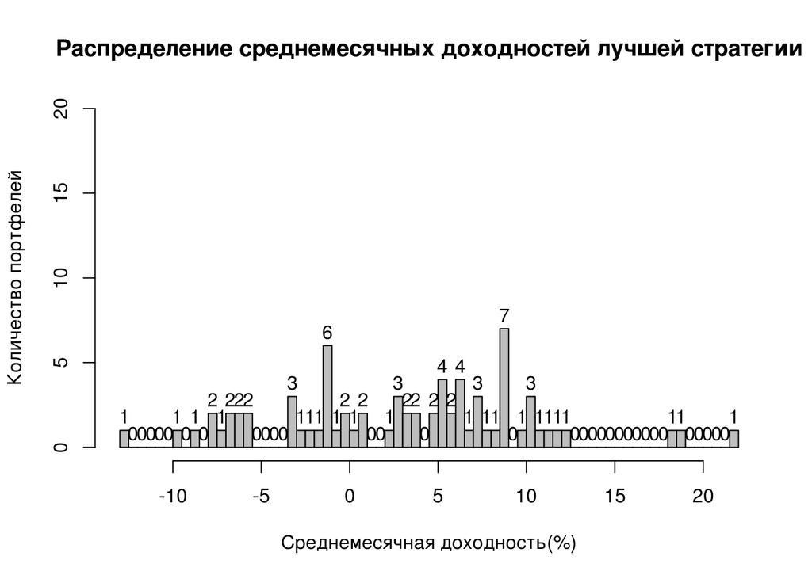

## 5. Моментум стратегии при весах (7,6,5,3,2,1,1,2,3,5,6,7)/24. Ранжирование по t-статистике (бенчмарк 6% годовых) для компаний с максимальной рыночной капитализацией (всего 32 компании)

> Лучшая по t-статистике стратегия дает среднемесячную доходность **2.03** **%** и имеет параметры: период отбора – **11** месяцев, период ожидания – **3** недель, период инвестирования – **6** месяцев

> Bootstrap p-value равен **0.294**

> Всего портфелей у лучшей по t-статистике стратегии – **74** Количество отрицательных доходностей у лучшей по t-статистике стратегии – **5** ( **6.76%** )

#### **Рисунок 8.**

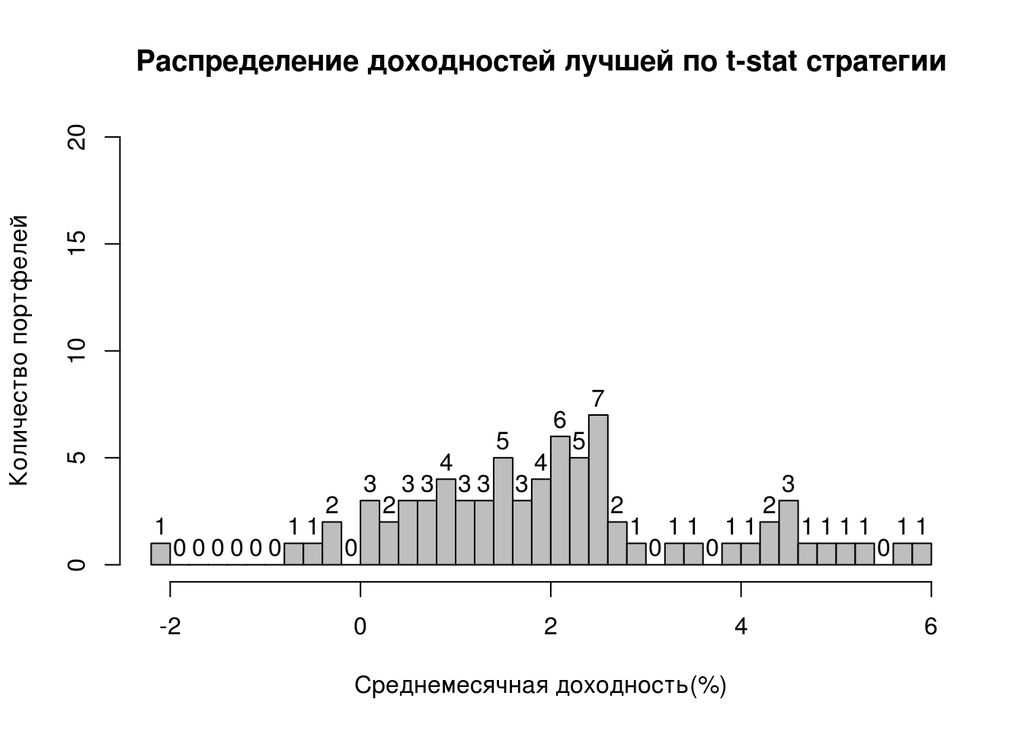